# Include name and location of the Fishery. One line only.

### Parameter Observations

#### Sampled Parameters

Histograms of 48 simulations of bias in observed natural mortality (`Mbias`), von Bertalanffy growth function parameters (`Linfbias`, `Kbias`, and `t0bias`), length-at-maturity (`lenMbias`), and bias in observed length at first capture (`LFCbias`) and first length at full capture (`LFSbias`) with vertical colored lines indicating 3 randomly drawn values:

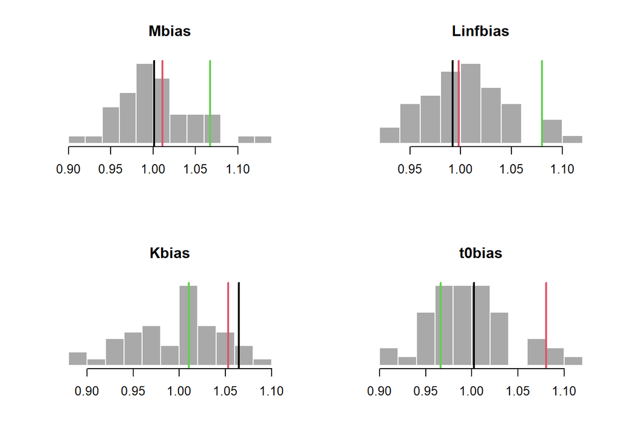

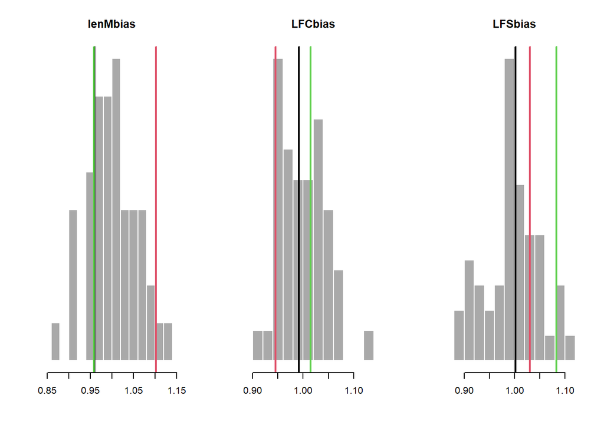

### Reference Point Observations

#### Sampled Parameters

Histograms of 48 simulations of bias in observed FMSY/M (`FMSY_Mbias`), BMSY/B0 (`BMSY_B0bias`), reference index (`Irefbias`), reference abundance (`Brefbias`) and reference catch (`Crefbias`), with vertical colored lines indicating 3 randomly drawn values:

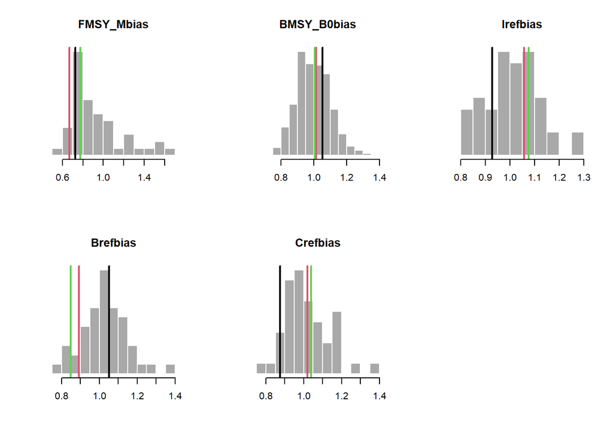

# Imp Parameters

### Output Control Implementation Error: TACFrac, TACSD

**TACFrac**: Mean fraction of TAC taken. Uniform distribution lower and upper bounds. Positive real number.

Specified Value(s): 1, 1

Borrowed from: Perfect_Imp

**TACSD**: Log-normal coefficient of variation in the fraction of Total Allowable Catch (TAC) taken. Uniform distribution lower and upper bounds. Non-negative real numbers.

Specified Value(s): 0, 0

Borrowed from: Perfect_Imp

### Effort Control Implementation Error: TAEFrac, TAESD

**TAEFrac**: Mean fraction of TAE taken. Uniform distribution lower and upper bounds. Positive real number.

Specified Value(s): 1, 1

Borrowed from: Perfect_Imp

**TAESD**: Log-normal coefficient of variation in the fraction of Total Allowable Effort (TAE) taken. Uniform distribution lower and upper bounds. Non-negative real numbers.

Specified Value(s): 0, 0

Borrowed from: Perfect_Imp

### Size Limit Control Implementation Error: SizeLimFrac, SizeLimSD

**SizeLimFrac**: The real minimum size that is retained expressed as a fraction of the size of retention. Uniform distribution lower and upper bounds. Positive real number.

Specified Value(s): 1, 1

Borrowed from: Perfect_Imp

**SizeLimSD**: Log-normal coefficient of variation controlling mismatch between a minimum size limit and the real minimum size retained. Uniform distribution lower and upper bounds. Non-negative real numbers.

Specified Value(s): 0, 0

Borrowed from: Perfect_Imp

## Implementation Parameters

### TAC Implementation

#### Sampled Parameters

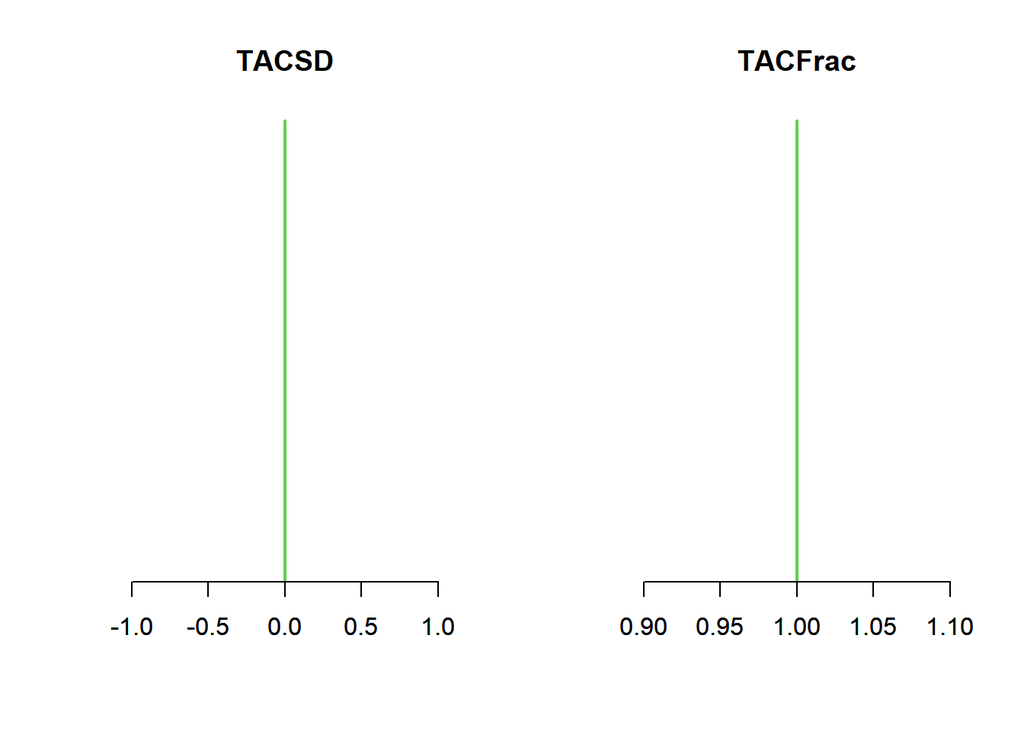

#### Time-Series

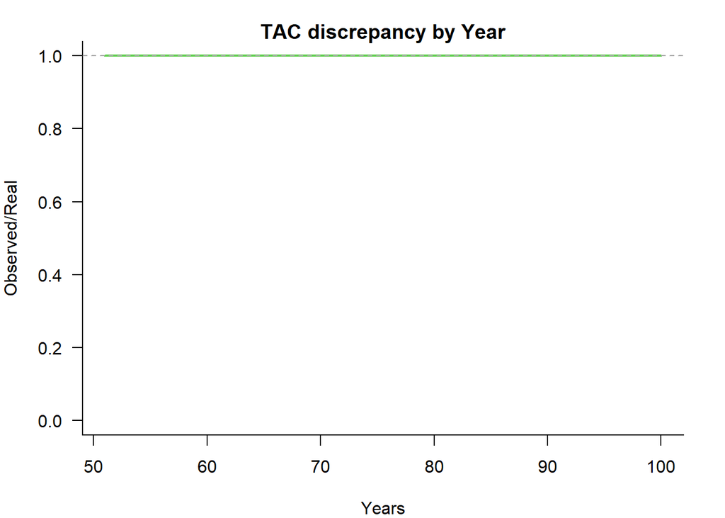

### TAE Implementation

#### Sampled Parameters

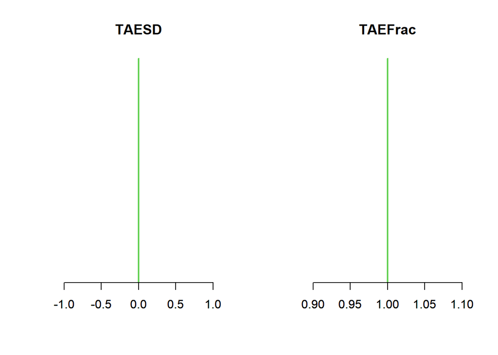

#### Time-Series

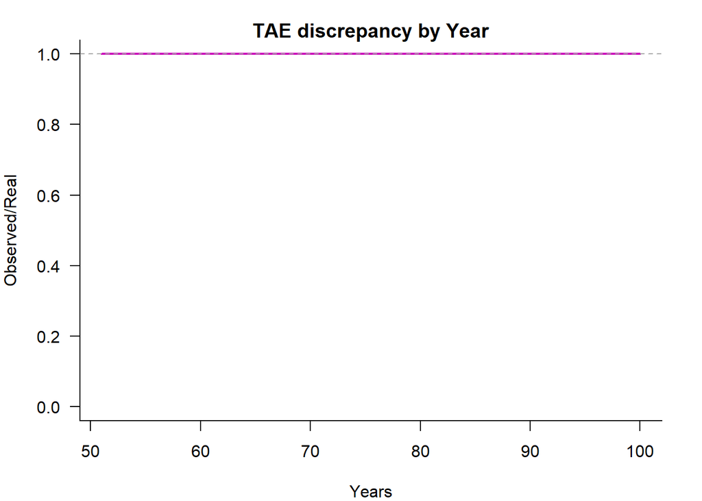

### Size Limit Implementation

#### Sampled Parameters

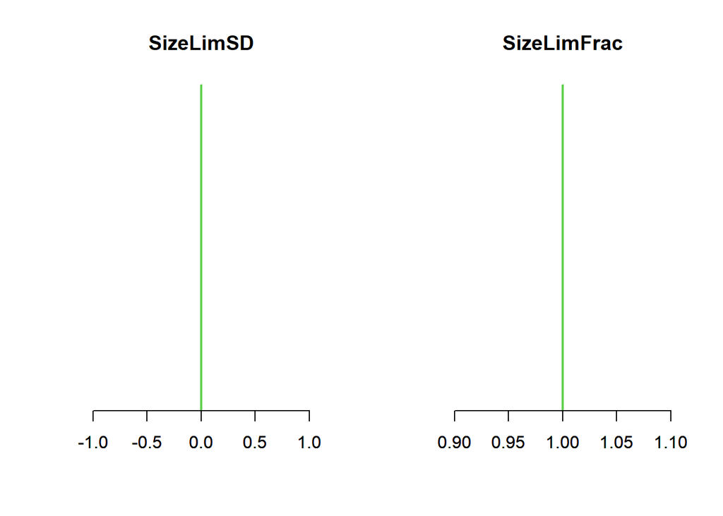

#### Time-Series

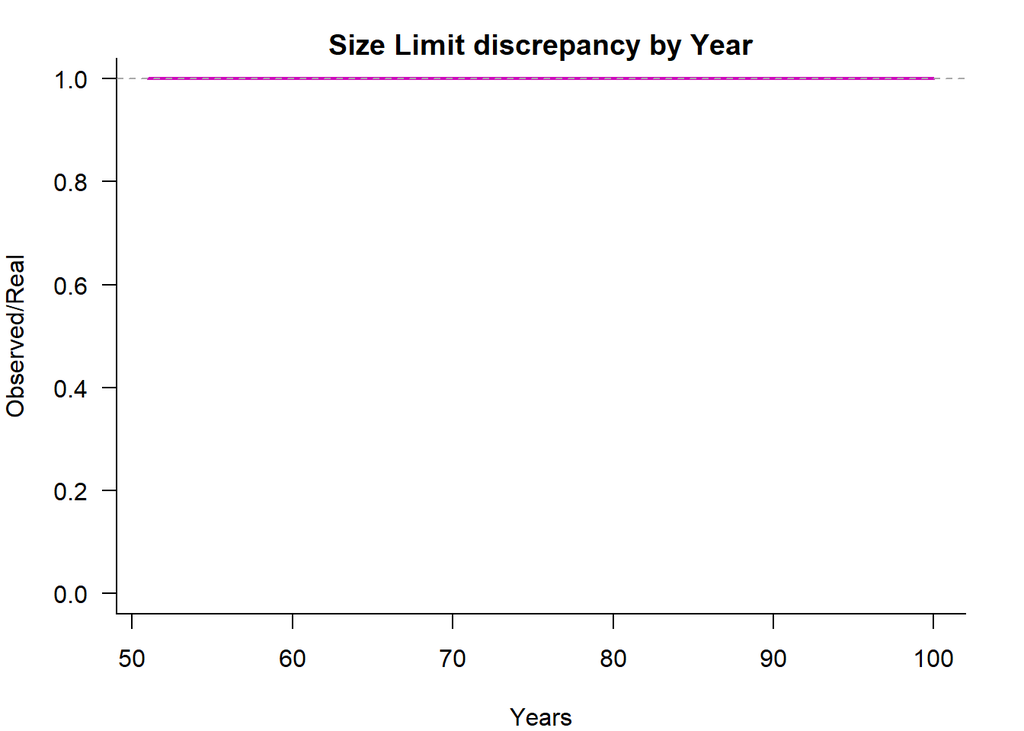

# Historical Simulation Plots

## Historical Time-Series

### Spawning Biomass

#### Depletion

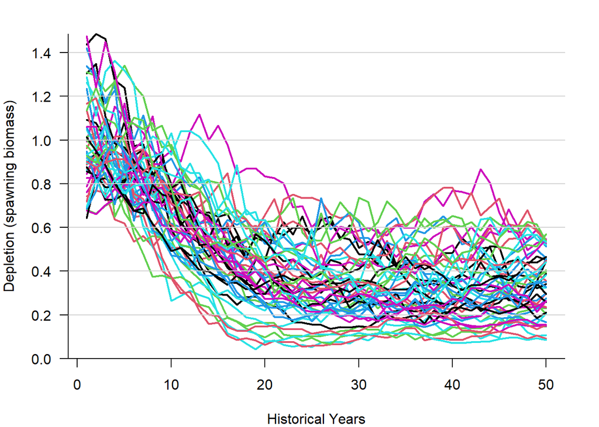

#### Absolute

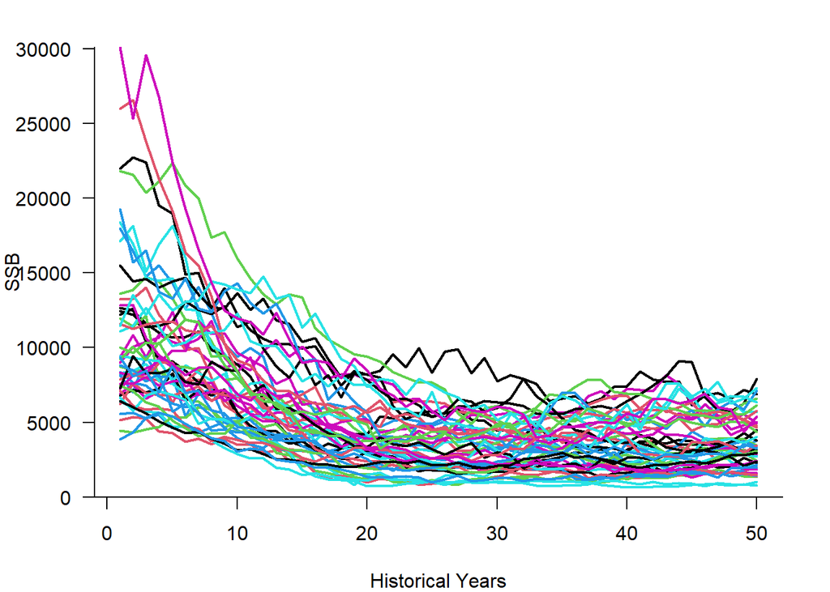

### Vulnerable Biomass

#### Depletion

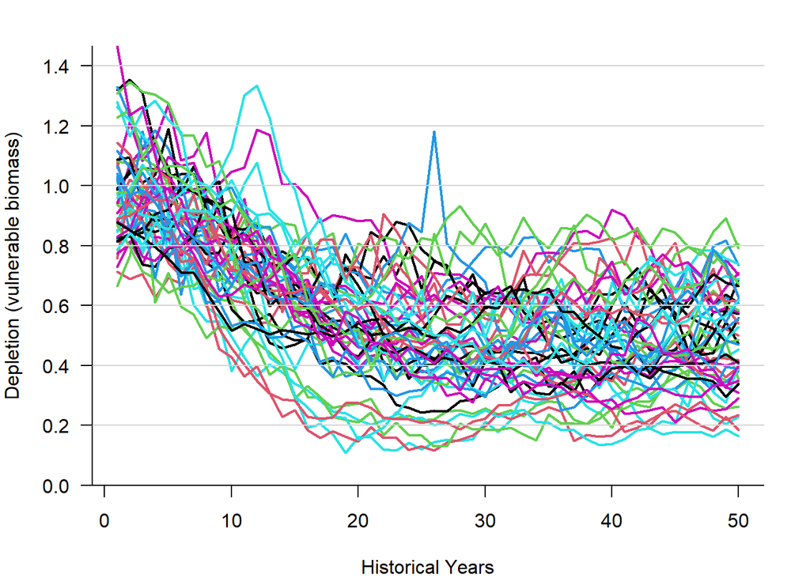

#### Absolute

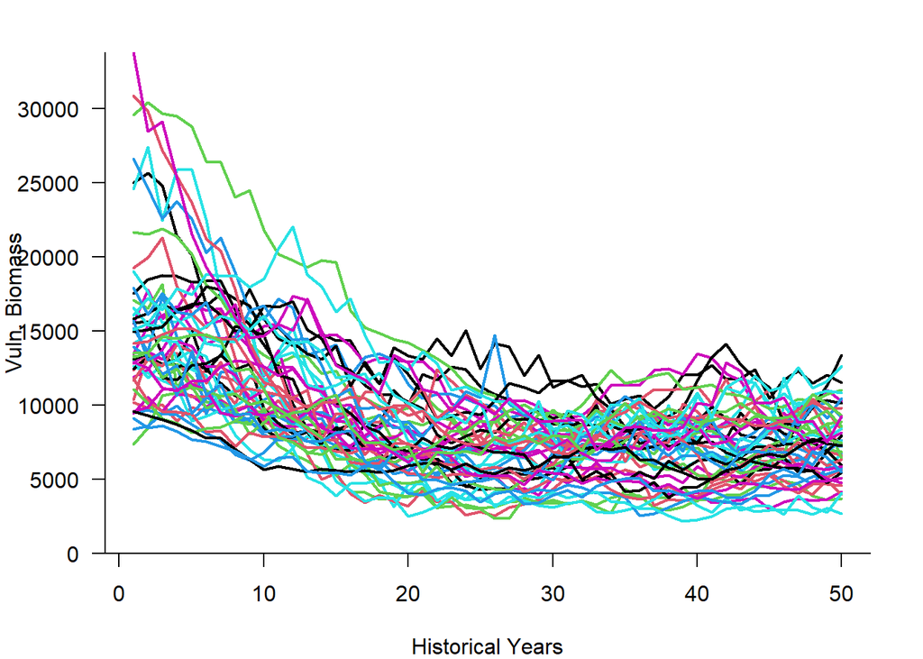

### Total Biomass

#### Depletion

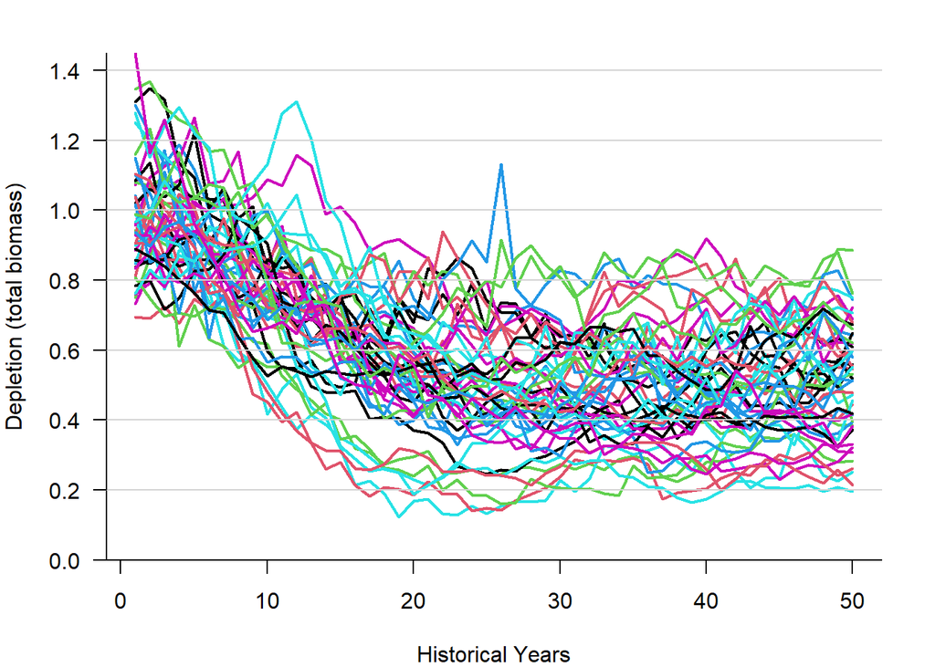

#### Absolute

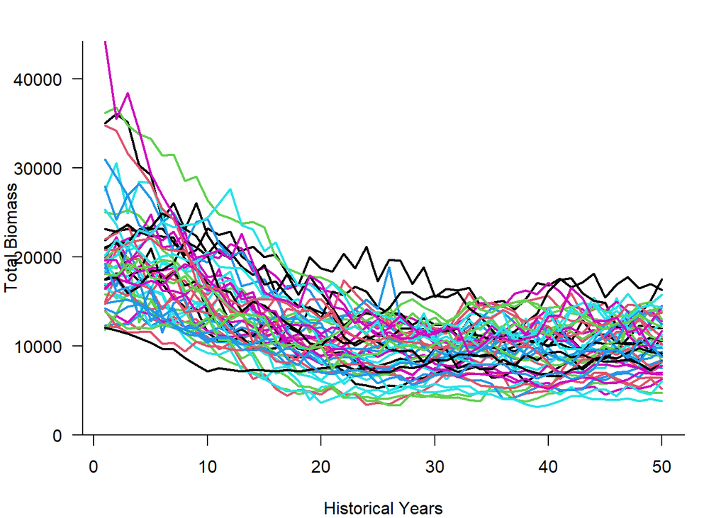

### Recruitment

#### Relative

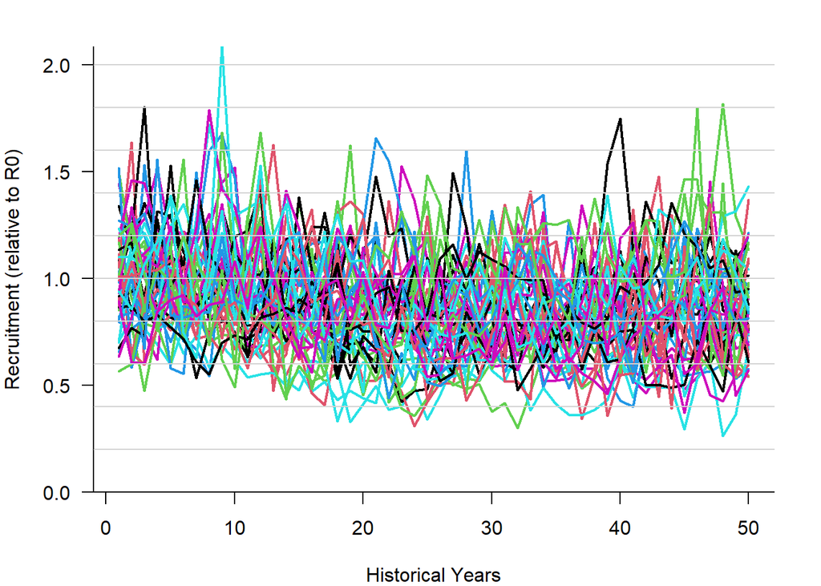

#### Absolute

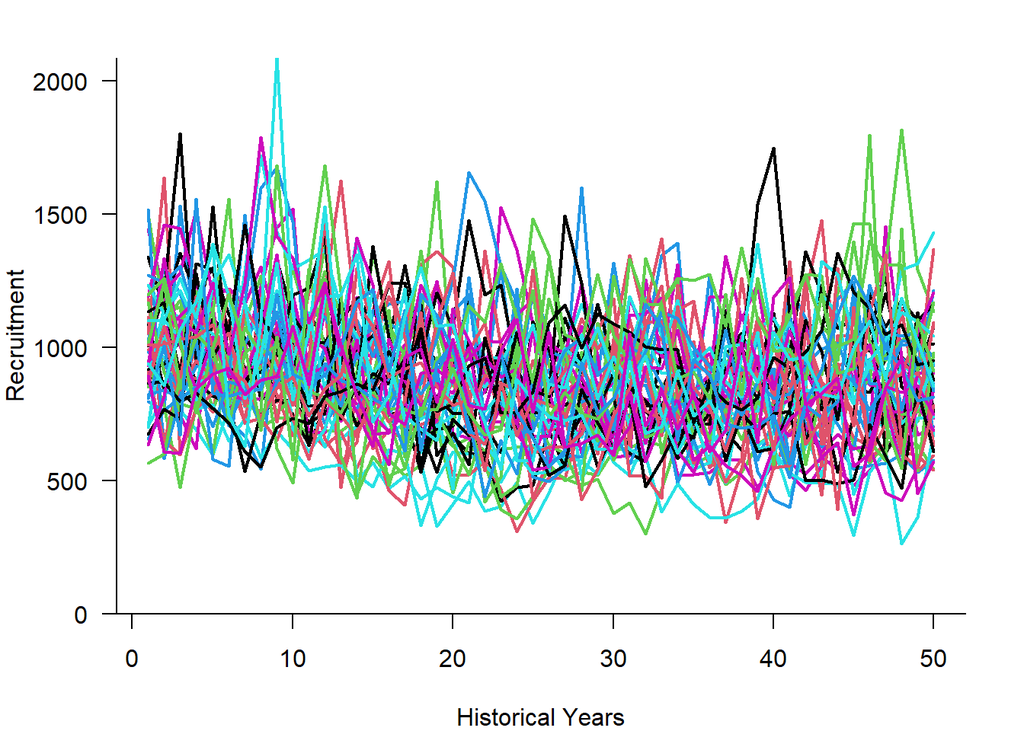

### Catch

#### Relative

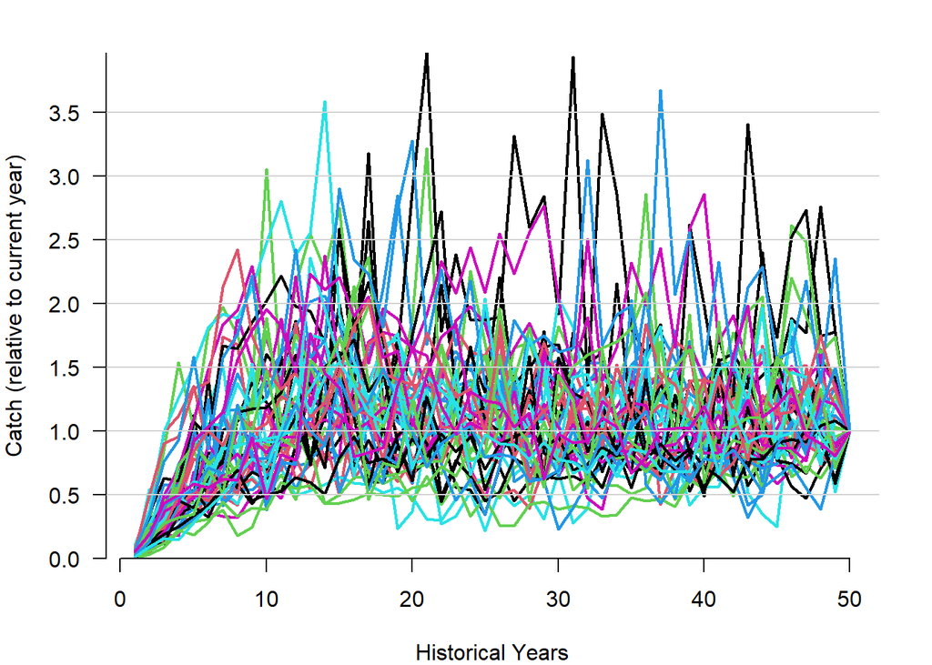

#### Absolute

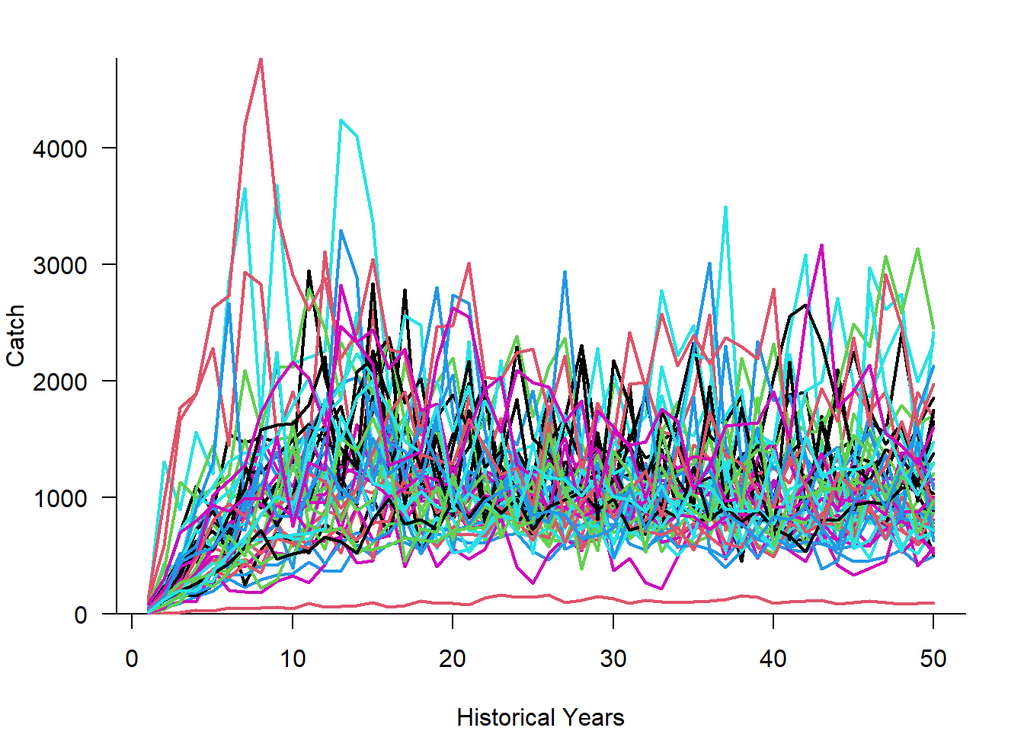

### Historical Fishing Mortality

#### Historical Time-Series

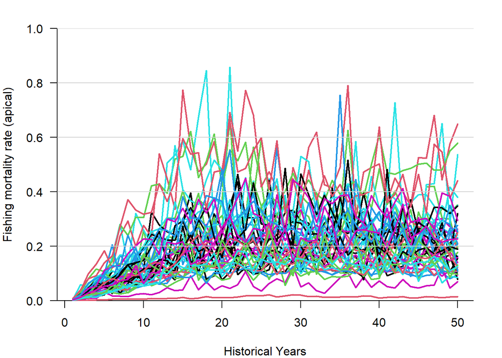